# PC3 stable line pollII ChIP

Jason T. Serviss

06/01/2017

# Introduction

miR34a asRNA over-expression was shown to increase the expression levels of miR34a. We investigated if this increase of miR34a was due to increased levels of transcription at the miR34a promoter.

# Methods

All cell lines were cultured at 5% CO2 and 37° C with Skov3 and PC3 cells in RPMI (Hyclone) and 2 mM L-glutamine and Saos2 cells cultured in DMEM high modified (Hyclone). All growth mediums were supplemented with 10% heat-inactivated FBS and 50 μg/ml of streptomycin and 50 μg/ml of penicillin. Cells were plated at 2-3x10^6 cells in a 15cm dish and incubated overnight. Cells were cross-linked in 1% formaldehyde, quenched in glycine (0.125M), resuspended in cell lysis buffer (5mM PIPES, 85mM KCL, 0.5% NP40, protease inhibitor), and sonicated (Bioruptor Sonicator Diagenode) in nucleus lysis buffer (50mM TRIS-HCL pH 8.0, 10mM EDTA, 1% SDS, protease inhibitor). The samples were incubated overnight at 4 °C with the appropriate antibody. Salmon sperm DNA/Protein A–agarose (Upstate/Millipore) was used to pull down the antibody. DNA was eluted in elution buffer (1% SDS, 100 mM NaHCO3), followed by reverse cross-linking, RNase-A and protease-K treatment. The DNA was eluted by using a Qiagen PCR purification kit. The following antibodies were used (4 μg/sample): phospho-polymerase II (abcam: ab5095). QPCR was carried out using KAPA 2G SYBRGreen (Kapa Biosystems) using the Applied Biosystems 7900HT machine with the cycling conditions: 95 °C for 3 min, 95 °C for 3 s, 60 °C for 30 s.

```r
primers <- data.frame(
    name=c(
        "miR34aChIP F1",
        "miR34aChIP R1"
    ),
    sequence=c(
       "AAA GTT TGC AAA GAA GGA GGC GGG",
       "AGG GAA GAA AGA ACT AGC CGA GCA"
    )
)
```

# Results

```r
library(reshape2)
library(ggplot2)
library(ggthemes)
library(plyr)
data <- read.table('~/GitHub/miR34aFigures/inst/StableLinePolIIChIP/ChIPdata.txt', header=TRUE, sep="\t")
data$meanQuantity <- rowMeans(data[ ,c("Quantity1", "Quantity2")])

percentPullDown <- ddply(
    data,
    c("experiment", "condition", "sample"),
    summarize,
    percentPullDown = meanQuantity/data[data$experiment == experiment & data$condition == condition & data$sample == "input", "meanQuantity"]
)
data <- merge(data, percentPullDown, by=c("experiment", "condition", "sample"), all.x=TRUE)
data$log2percentPulldown <- log2(data$percentPullDown)
data <- subset(data, sample != "input")

ASminusMock <- ddply(
    data,
    c("experiment"),
    summarize,
    condition=unique(condition),
    ASminusMock = log2percentPulldown - data[data$experiment == experiment & data$condition == "mock", "log2percentPulldown"]
)
data <- merge(data, ASminusMock, by=c("experiment", "condition"), all.x=TRUE)

data$antilogASminusMock <- 2^data$ASminusMock

#calculate stats
t <- t.test(data[data$condition != "mock", "ASminusMock"])
pValue <- t$p.value
CI95l <- t$conf.int[1]
CI95h <- t$conf.int[2]

#calculate summary
stats <- ddply(
    data,
    c("condition"),
    summarize,
    mean = mean(ASminusMock)
)

stats$CI95l <- c(CI95l, 1)
stats$CI95h <- c(CI95h, 1)

pBars <- data.frame(
    condition=c("mock", "miR34a AS"),
    xend = c(0,2),
    x=c(0,1),
    xStars=c(0,1.5),
    pStars=c("", "\u2605")
)

stats <- merge(stats, pBars, by="condition")
data <- merge(data, stats, by=c("condition"), all.x=TRUE)
data$condition <- as.character(data$condition)
data[data$condition == "miR34a AS", "condition"] <- "miR34a\nasRNA"
data$condition <- factor(data$condition, levels=c("mock", "miR34a\nasRNA"))
#data <- droplevels(data[data$condition == "miR34a AS",])
```

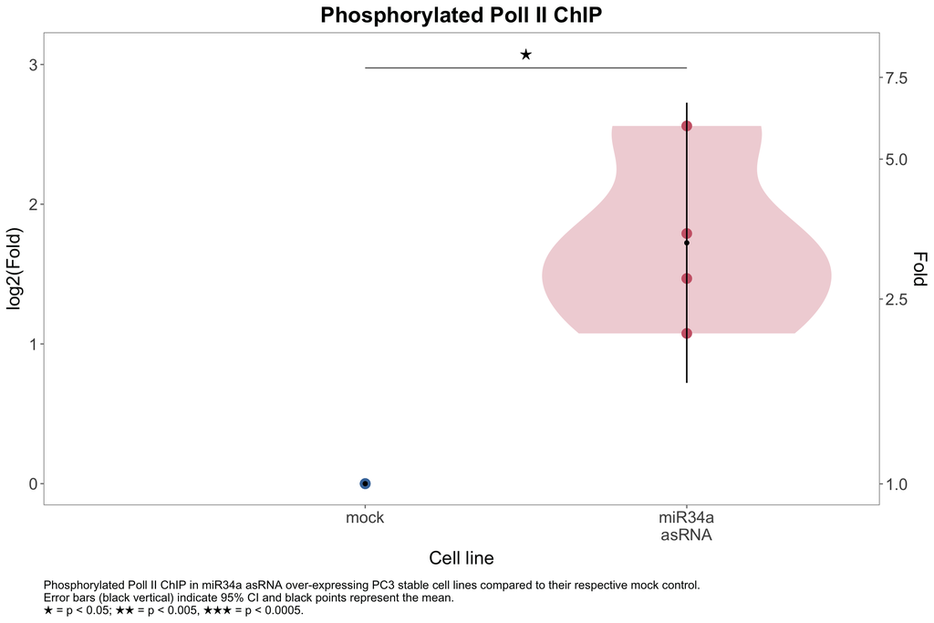

```r
#plot for Rmarkdown
ggplot(data, aes(x=condition, y=ASminusMock))+
    geom_violin(
        aes(fill=condition),
        trim=TRUE,
        #scale="width",
        alpha=0.3,
        colour=NA,
        show.legend = FALSE
    )+
    geom_point(
        aes(colour=condition),
        size=4
    )+
    geom_linerange(
        aes(ymin=CI95l, ymax=CI95h),
        colour="black",
        show.legend = FALSE
    )+
    geom_point(
        aes(y=mean),
        colour="black",
        show.legend = FALSE
    )+
    geom_segment(
        aes(x=x, y=CI95h+0.25, xend=xend, yend=CI95h+0.25),
        colour="grey43"
    )+
    geom_label(
        aes(x=xStars, y=CI95h+0.35, label=pStars),
        label.size=0,
        label.padding=unit(0.01, "lines"),
        show.legend = FALSE,
        fill="white",
        size=5,
        family="Arial Unicode MS"
    )+
    scale_y_continuous(
        "log2(Fold)",
        sec.axis = sec_axis(
            ~2^.,
            name = "Fold",
            breaks=c(1,2.5,5,7.5)
        )
    )+
    labs(
      x="Cell line",
      y="log2(Fold polII enrichment)",
      title="Phosphorylated Poll II ChIP",
      caption=
            "Phosphorylated Poll II ChIP in miR34a asRNA over-expressing PC3 stable cell lines compared to their respective mock control.\nError bars (black vertical) indicate 95% CI and black points represent the mean.\n\u2605 = p < 0.05; \u2605\u2605 = p < 0.005, \u2605\u2605\u2605 = p < 0.0005."
    )+
    theme_few()+
    scale_fill_ptol()+
    scale_color_ptol()+
    theme(
        plot.title = element_text(
            hjust = 0.5,
            face="bold",
            size=20
        ),
        plot.caption = element_text(
            hjust=0,
            margin=margin(t=15),
            family="Arial Unicode MS"
        ),
        legend.position="none",
        axis.title=element_text(size=17),
        axis.title.x=element_text(margin=margin(t=10)),
        axis.text=element_text(size=15)
    )
```

```r
#plot for pdf
p <- ggplot(data, aes(x=condition, y=ASminusMock))+
    geom_violin(
        aes(fill=condition),
        trim=TRUE,
        #scale="width",
        alpha=0.3,
        colour=NA,
        lwd=0.1
    )+
    #geom_point(
    #    aes(colour=condition),
    #    size=1
    #)+
    geom_linerange(
        aes(ymin=CI95l, ymax=CI95h),
        colour="black",
        show.legend = FALSE,
        lwd=0.15
    )+
    geom_point(
        aes(y=mean),
        colour="black",
        size=0.5,
        show.legend = FALSE
    )+
    geom_segment(
        aes(x=x, y=CI95h+0.25, xend=xend, yend=CI95h+0.25),
        colour="grey43",
        lwd=0.15
    )+
    geom_label(
        aes(x=xStars, y=CI95h+0.4, label=pStars),
        label.size=0,
        label.padding=unit(0.01, "lines"),
        show.legend = FALSE,
        fill="white",
        size=1,
        family="Arial Unicode MS"
    )+
    #scale_y_continuous(
    #    "log2(Fold)",
    #    sec.axis = sec_axis(
    #        ~2^.,
    #        name = "Fold",
    #        breaks=c(1,2.5,5,7.5)
    #    )
    #)+
    labs(
      x="Cell line",
      y="log2(Fold polII enrichment)"
      #title="Phosphorylated Poll II ChIP"
    )+
    theme_few()+
    scale_fill_ptol()+
    scale_color_ptol()+
    theme(
        plot.title = element_text(
            hjust = 0.5,
            face="bold",
            size=10
        ),
        plot.margin = unit(rep(0.1,4), "lines"),
        legend.position="none",
        axis.title=element_text(size=9),
        axis.title.x=element_text(margin=margin(t=5)),
        axis.text=element_text(size=8),
        axis.ticks.length = unit(1/15, "cm"),
        axis.ticks = element_line(size=0.25),
        panel.border = element_rect(fill=NA, size=0.15),
        panel.margin=unit(2, "mm")
    )

ggsave(plot=p, filename="~/GitHub/miR34aFigures/inst/StableLinePolIIChIP/StableLinePolIIChIP.pdf", device=cairo_pdf, height=60, width=43, units="mm") #83
```

# Conclusion

Phosphorylated pol-II was increased at the miR34a promoter in miR34a asRNA over-expressing cell lines indicating that the regulation of miR34a by miR34a asRNA is transcriptional.